# 2. Rasterio Clip Operations

## 2. Masking AKA Clipping with Rasterio

Okay--I admit this is slightly complicated, but doing GIS in the wild can be that way sometimes!

There's a bunch of ways you may want to clip something, so consider this a primer on what it really takes to clip a raster.  
Essentially, you need:

1. An input image
2. Something you want to clip it with, in this case, we'll use geometries from a shapefile
3. You need the geometry of the clipping object as a [geojson-like dict](https://rasterio.readthedocs.io/en/stable/api/rasterio.mask.html)
4. And of course you need all of the critical descriptive information to go along with these such as the CRS, the transformation, the width, the height, the color profile...

Let's do it!

```python
import rasterio as rio
from rasterio.plot import show
from rasterio.mask import mask #this is the masking aka clip module
import matplotlib.pyplot as plt
import geopandas as gpd #to read the input shapefile
import shapely #to transform extent into coordinate geometries
import json
import os
```

Important: only run this once or you'll wind up in the wrong directory.

```
os.chdir('../')
os.getcwd()
```

First, let's read in the image:

```
src = rio.open('workshopdata/NAIP_Campus.tif')
```

```python
src = rio.open('workshopdata/NAIP_Campus.tif')
```

Let's take a peek:

```
show(src.read(1))
```

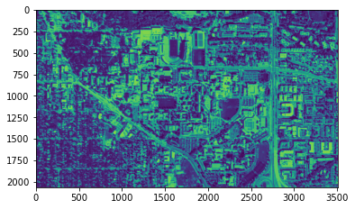

```python
show(src.read(1))
```

Let's clip so that we're only working with the quad area...

Read in the campus shapefile:

```
shape = gpd.read_file('workshopdata/UCB_MainCampus_Boundaries.shp')
```

```python
shape = gpd.read_file('workshopdata/UCB_MainCampus_Boundaries.shp')
```

Let's take a look:

```
shape.plot(figsize = (12,12))
```

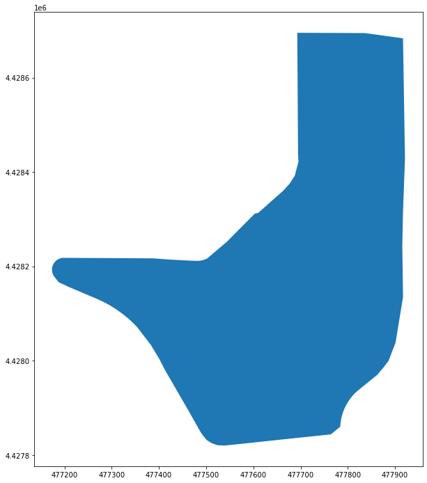

```python
shape[22:23].plot(figsize = (12,12))
```

Okay, but if we're going to clip with this, it needs to be in the same CRS as the image, this is easy to change using geopandas:

```
src.crs
```

```python
src.crs
```

```
CRS.from_epsg(26913)
```

Change it to EPSG 26913

```
shape = shape.to_crs(26913)
```

```python
shape = shape.to_crs(26913)
```

Now, let's get the geometry of the southwest part of main campus:

We'll use GeoPandas to access the geometry of that particular feature.

```
swQuad = shape.geometry[22]
```

```python
swQuad = shape.geometry[22]
```

### Okay...

From the Rasterio docs: The values must be a GeoJSON-like dict or an object that implements the Python geo interface protocol (such as a [Shapely](https://shapely.readthedocs.io/en/stable/geometry.html) Polygon).

Fortunately, that's what we have:

```
print(swQuad)
```

```python
print(swQuad)
```

```
POLYGON ((477547.8159370111 4428256.238502387, 477603.2191063287 4428311.991142652, 477610.260153695 4428313.372457464, 477663.4512336894 4428360.636259837, 477676.9024611069 4428375.471382552, 477687.7264066462 4428392.210929826, 477695.4980979763 4428422.068033623, 477694.6469493901 4428437.489914…
```

Perfect!

Now finally, we can run the mask function to get the clipped image. mask() will return two things: the image, and it's affine transformation. You must set crop to True--without it, the image will be the same size but with no values beyond our clip area. Setting crop to True gets rid of those areas:

```
out_img, out_transform = mask(src, [swQuad], crop=True)
```

** One other caveat: wrap the swQuad variable in square brackets so rasterio knows to treat it like an iterable.

```python
out_img, out_transform = mask(src, [swQuad], crop=True)
```

Let's take a look...

```
show(out_img)
```

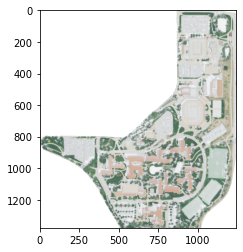

```python
show(out_img)
```

### ...but...

Okay, maybe you don't want it clipped to the exact geometry... maybe you would rather have it by the extent of the geometry?

Okay, let's do it!

```
envelope = swQuad.envelope
envelope
```

```python
envelope = swQuad.envelope
envelope
```

print it...

```python
print(envelope)
```

```
POLYGON ((477173.6093709322 4427820.357116409, 477921.0539890607 4427820.357116409, 477921.0539890607 4428695.097440739, 477173.6093709322 4428695.097440739, 477173.6093709322 4427820.357116409))
```

#### Siiiick!

Now, let's do it again, this time with the envelope as the geometry object:

```
out_img, out_transform = mask(src, [envelope], crop=True)
```

```python
out_img, out_transform = mask(src,[envelope], crop=True)
```

Check it out:

```
show(out_img)
```

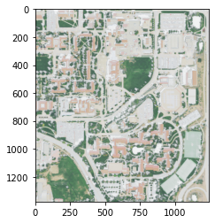

```python
show(out_img)
```

### Awesome. If the color looks funny, we'll sort that out when we save it...

Now, let's get the original profile

```
src.profile
```

```python
src.profile
```

[output not shown]

Copy it to a variable:

```
profile = src.profile.copy()
```

(Note, this is the same as the kwargs variable we used in the last notebook)

```python
profile = src.profile.copy()
```

Grab the height and the width of the output image:

```
height = out_img.shape[1]
width = out_img.shape[2]
```

```python
height = out_img.shape[1]
width = out_img.shape[2]
```

Update the profile. Since we have a new transform, a new width & height, we need to use the `.update` method to take the old profile and update certain elements:

```
profile.update(transform = out_transform,
               width = width,
               height = height,
               photometric = 'rgb',
               alpha = 'no')
```

(more on photometric & alpha in the next notebook)

```python
profile.update(transform = out_transform, width = width, height = height, photometric = 'rgb', alpha = 'no')
```

Open a new empty dataset:

```
new = rio.open('NAIP_swQuad.tif', 'w', **profile)
```

```python
new = rio.open('NAIP_swQuad.tif', 'w', **profile)
```

Write it to disc:

```
new.write(out_img)
```

```python
new.write(out_img)
```

Close it...

```
new.close()
```

```python
new.close()
```